# Data621_hw1

Wei Zhou

2/29/2020

## Read Data

```
##   TARGET_WINS BATTING_H BATTING_2B BATTING_3B BATTING_HR BATTING_BB
## 1          39      1445        194         39         13        143
## 2          70      1339        219         22        190        685
## 3          86      1377        232         35        137        602
## 4          70      1387        209         38         96        451
## 5          82      1297        186         27        102        472
## 6          75      1279        200         36         92        443
##   BATTING_SO BASERUN_SB BASERUN_CS BATTING_HBP PITCHING_H PITCHING_HR
## 1        842         NA         NA          NA       9364          84
## 2       1075         37         28          NA       1347         191
## 3        917         46         27          NA       1377         137
## 4        922         43         30          NA       1396          97
## 5        920         49         39          NA       1297         102
## 6        973        107         59          NA       1279          92
##   PITCHING_BB PITCHING_SO FIELDING_E FIELDING_DP
## 1         927        5456       1011          NA
## 2         689        1082        193         155
## 3         602         917        175         153
## 4         454         928        164         156
## 5         472         920        138         168
## 6         443         973        123         149
```

## 1. DATA EXPLORATION (25 Points)

Describe the size and the variables in the moneyball training data set. Consider that too much detail will cause a manager to lose interest while too little detail will make the manager consider that you aren’t doing your job. Some suggestions are given below. Please do NOT treat this as a check list of things to do to complete the assignment. You should have your own thoughts on what to tell the boss. These are just ideas.

### a. Mean / Standard Deviation / Median

```r
summary(train)
```

```
##   TARGET_WINS       BATTING_H      BATTING_2B      BATTING_3B
##  Min.   :  0.00   Min.   : 891   Min.   : 69.0   Min.   :  0.00
##  1st Qu.: 71.00   1st Qu.:1383   1st Qu.:208.0   1st Qu.: 34.00
##  Median : 82.00   Median :1454   Median :238.0   Median : 47.00
##  Mean   : 80.79   Mean   :1469   Mean   :241.2   Mean   : 55.25
##  3rd Qu.: 92.00   3rd Qu.:1537   3rd Qu.:273.0   3rd Qu.: 72.00
##  Max.   :146.00   Max.   :2554   Max.   :458.0   Max.   :223.00
##
##    BATTING_HR       BATTING_BB      BATTING_SO       BASERUN_SB
##  Min.   :  0.00   Min.   :  0.0   Min.   :   0.0   Min.   :  0.0
##  1st Qu.: 42.00   1st Qu.:451.0   1st Qu.: 548.0   1st Qu.: 66.0
##  Median :102.00   Median :512.0   Median : 750.0   Median :101.0
##  Mean   : 99.61   Mean   :501.6   Mean   : 735.6   Mean   :124.8
##  3rd Qu.:147.00   3rd Qu.:580.0   3rd Qu.: 930.0   3rd Qu.:156.0
##  Max.   :264.00   Max.   :878.0   Max.   :1399.0   Max.   :697.0
##                                   NA's   :102      NA's   :131
##    BASERUN_CS     BATTING_HBP      PITCHING_H     PITCHING_HR
##  Min.   :  0.0   Min.   :29.00   Min.   : 1137   Min.   :  0.0
##  1st Qu.: 38.0   1st Qu.:50.50   1st Qu.: 1419   1st Qu.: 50.0
##  Median : 49.0   Median :58.00   Median : 1518   Median :107.0
##  Mean   : 52.8   Mean   :59.36   Mean   : 1779   Mean   :105.7
##  3rd Qu.: 62.0   3rd Qu.:67.00   3rd Qu.: 1682   3rd Qu.:150.0
##  Max.   :201.0   Max.   :95.00   Max.   :30132   Max.   :343.0
##  NA's   :772     NA's   :2085
##   PITCHING_BB      PITCHING_SO        FIELDING_E      FIELDING_DP
##  Min.   :   0.0   Min.   :    0.0   Min.   :  65.0   Min.   : 52.0
##  1st Qu.: 476.0   1st Qu.:  615.0   1st Qu.: 127.0   1st Qu.:131.0
##  Median : 536.5   Median :  813.5   Median : 159.0   Median :149.0
##  Mean   : 553.0   Mean   :  817.7   Mean   : 246.5   Mean   :146.4
##  3rd Qu.: 611.0   3rd Qu.:  968.0   3rd Qu.: 249.2   3rd Qu.:164.0
##  Max.   :3645.0   Max.   :19278.0   Max.   :1898.0   Max.   :228.0
##                   NA's   :102                        NA's   :286
```

```r
apply(train, 2, sd, na.rm = TRUE)
```

```
## TARGET_WINS   BATTING_H  BATTING_2B  BATTING_3B  BATTING_HR  BATTING_BB
##    15.75215   144.59120    46.80141    27.93856    60.54687   122.67086
##  BATTING_SO  BASERUN_SB  BASERUN_CS BATTING_HBP  PITCHING_H PITCHING_HR
##   248.52642    87.79117    22.95634    12.96712  1406.84293    61.29875
## PITCHING_BB PITCHING_SO  FIELDING_E FIELDING_DP
##   166.35736   553.08503   227.77097    26.22639
```

### b. Bar Chart or Box Plot of the data

```r
library(reshape)
```

```r
library(ggplot2)

par(mfrow = c(3, 3))

datasub = melt(train)
```

```
## Using  as id variables
```

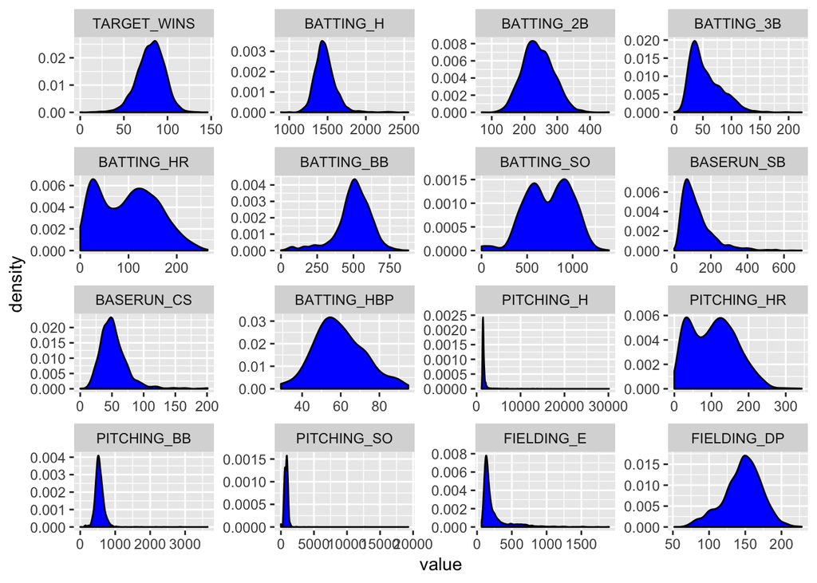

```r
ggplot(datasub, aes(x= value)) +
    geom_density(fill='blue') +
    facet_wrap(~variable, scales = 'free')
```

### c. Is the data correlated to the target variable (or to other variables?)

Findings: 1. TEAM_BATTING_H exhibits the highest correlation to the response variable, 2. TEAM_FIELDING_E exhibits the lowest correlation 3. Both TEAM_PITCHING_HR and TEAM_PITCHING_BB exhibit positive correlations to the response variable

[figure not shown]

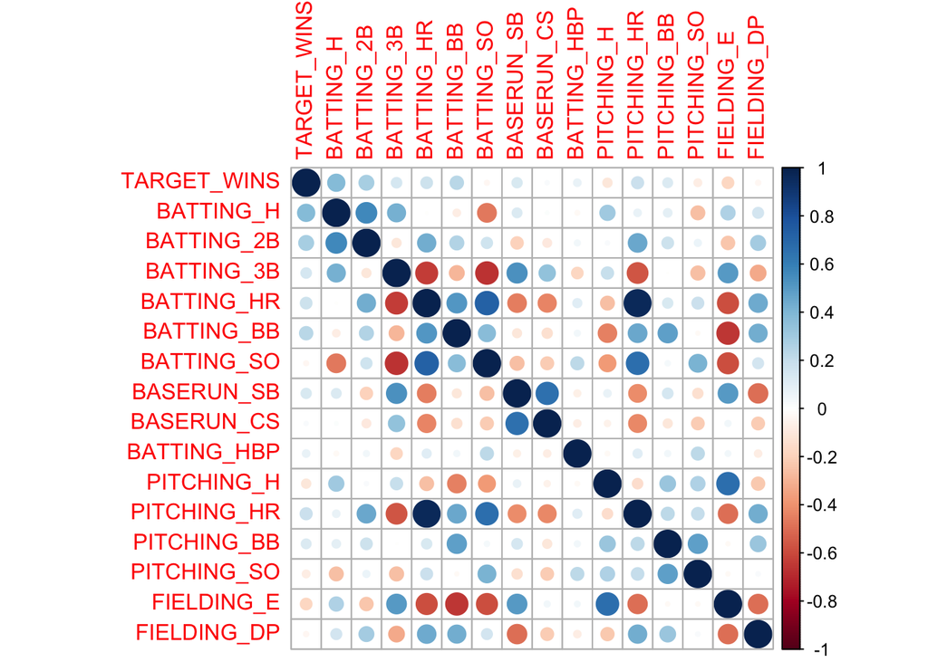

```r
library(corrplot)
library(corrgram)
corrplot(corrgram(train), method="circle")
```

### d. Are any of the variables missing and need to be imputed “fixed”?

[output not shown]

[output not shown]

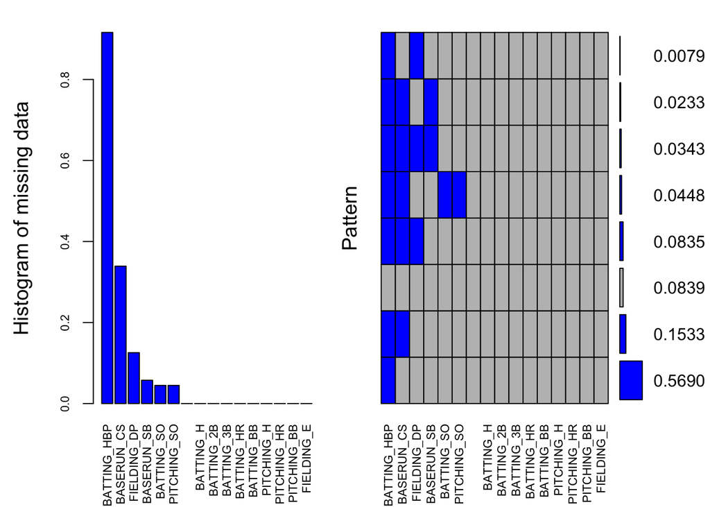

```
##
##  Variables sorted by number of missings:
##     Variable      Count
##  BATTING_HBP 0.91608084
##   BASERUN_CS 0.33919156
##  FIELDING_DP 0.12565905
##   BASERUN_SB 0.05755712
##   BATTING_SO 0.04481547
##  PITCHING_SO 0.04481547
##  TARGET_WINS 0.00000000
##    BATTING_H 0.00000000
##   BATTING_2B 0.00000000
##   BATTING_3B 0.00000000
##   BATTING_HR 0.00000000
##   BATTING_BB 0.00000000
##   PITCHING_H 0.00000000
##  PITCHING_HR 0.00000000
##  PITCHING_BB 0.00000000
##   FIELDING_E 0.00000000
```

## 2. DATA PREPARATION (25 Points)

Describe how you have transformed the data by changing the original variables or creating new variables. If you did transform the data or create new variables, discuss why you did this. Here are some possible transformations. a. Fix missing values (maybe with a Mean or Median value) b. Create flags to suggest if a variable was missing c. Transform data by putting it into buckets d. Mathematical transforms such as log or square root (or use Box-Cox) e. Combine variables (such as ratios or adding or multiplying) to create new variables

### Missing imputation

```r
train_clean = train
train_clean = train_clean %>%
                  mutate(BATTING_1B = BATTING_H - BATTING_2B - BATTING_3B - BATTING_HR) %>%
                  select(-BATTING_H)
```